# Draft - Final Report

Group 14

2024-05-16

# 1. Overview

## 1.1. Description of the Problem

Accurate risk assessment and mitigation strategies are crucial for loan provision, making it a complex and time-consuming process for banking institutions (Alagic et al., 2024). For lenders, credit risk analysis is essential as it concerns the borrower’s ability to repay the loan, which is the core of credit scoring (Moscato et al., 2021).

In this project, our group took a dataset containing information on customers who took out loans and used it to classify whether the customer has a **good, standard, or poor credit score.** This classification will be determined from several features, such as how the customer pays each month, monthly income, payment behaviour, credit utilisation ratio, etc. The goal is to help banks add additional assessment on loan eligibility and reduce financial risks.

## 1.2 Dataset Description

This dataset contains information 100,000 bank customers across 28 features (12 categorical and 16 numerical). It includes details on income, accounts, loans, credit history, and payment behavior. The goal is to use this data for credit score analysis, specifically to classify customers into good, standard, or poor credit categories.

## 1.3. Initial Data Analysis

```r
# Read
df <- read.csv("cleaned-train.csv") %>% dplyr::select(-X)
```

An initial data analysis is concluded to identify the data patterns, attributes, and other characteristics to reduce assumptions about the data.There are some key findings found.

First, it is found that the **dataset is imbalaced** toward the Standard Class, with a **ratio** of the classes (Good: Poor: Standard) being **18 :29 :53**. The ratio and count of each of the classes can be seen in the figure below.

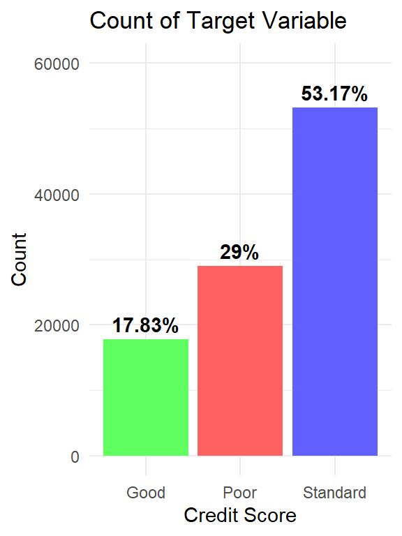

```r
colors <- c("Good" = "#60FF60",
            "Standard" = "#6060FF",
            "Poor" = "#FF6060")

dftab <- df %>%
  count(Credit_Score) %>%
  mutate(perc = round(100*n/sum(n), 2))

ggplot(dftab, aes(x=Credit_Score, y=n, fill = Credit_Score)) +
  ylim(0,60000) +
  geom_bar(stat="identity", show.legend = FALSE) +
  geom_text(aes(label = paste0(perc, "%")),
            position = position_dodge(.9),
            vjust = -0.5,
            colour = "black", fontface='bold'
  ) +
  theme_minimal() +
  scale_fill_manual("legend", values =colors) +
  ylab("Count") +
  xlab("Credit Score") +
  ggtitle("Count of Target Variable")
```

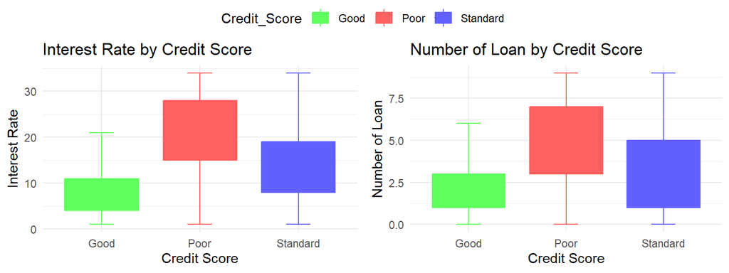

```r
p1 <- ggplot(df[order(df$Credit_Score),], aes(y = Interest_Rate, x = Credit_Score, color = Credit_Score, fill = Credit_Score)) +
  geom_boxplot(outliers = FALSE) +
  stat_boxplot(geom = "errorbar", width = 0.25) +
  scale_color_manual(values = colors) +
  scale_fill_manual(values = colors) +
  labs(title = "Interest Rate by Credit Score", x = "Credit Score", y = "Interest Rate") +
  theme_minimal()
p2 <- ggplot(df[order(df$Credit_Score),], aes(y = Num_of_Loan, x = Credit_Score, color = Credit_Score, fill = Credit_Score)) +
  geom_boxplot(outliers = FALSE) +
  stat_boxplot(geom = "errorbar", width = 0.25) +
  scale_color_manual(values = colors) +
  scale_fill_manual(values = colors) +
  labs(title = "Number of Loan by Credit Score", x = "Credit Score", y = "Number of Loan") +
  theme_minimal()

p12 <- ggarrange(p1, p2, common.legend = TRUE)
p12
```

A t-SNE plot is also createdl. Although the t-SNE visualization didn’t show clear clusters, the dataset remains valuable for machine learning classification. Further exploration, feature engineering, and alternative algorithms can unlock hidden patterns and enable accurate predictive models.

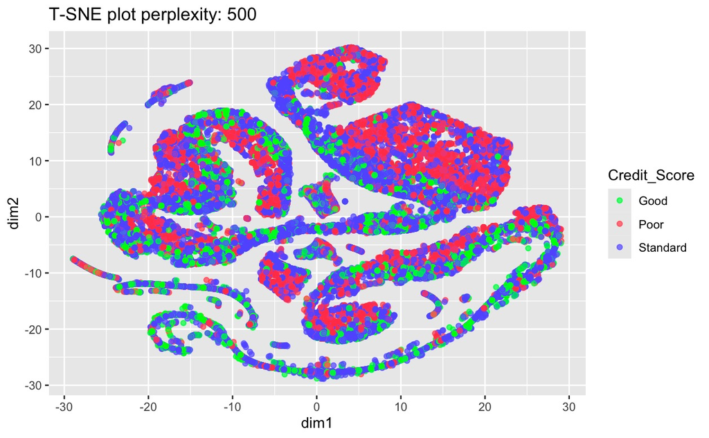

```r
# library(Rtsne)
#
# It Require 1 Hour to run this R-TSNE
#
# data <- df %>%
#           na.exclude %>%
#           dplyr::select(-c("Customer_ID", "ID", "Name", "SSN")) %>%
#           select_if(is.numeric)

# p = 500
# tsne_out <- Rtsne(as.matrix(data), perplexity=p)
# print(paste0("Perplexity :", p))
#
# tsne_plot <- data.frame(x = tsne_out$Y[,1],
#                       y = tsne_out$Y[,2],
#                       Credit_Score = as.factor(df$Credit_Score))
#
# colors <- c("Good" = "#60FF60",
#             "Standard" = "#6060FF",
#             "Poor" = "#FF6060")
# alpha <- c("Good" = 1,
#             "Standard" = 1,
#             "Poor" = 1)
# ggplot(tsne_plot,label=Credit_Score, aes(x=x,y=y, colour = Credit_Score, alpha= Credit_Score)) +
#   geom_point(alpha=0.7) +
#   scale_color_manual(values=colors) +
#   scale_alpha_manual(values=alpha) +
#   ggtitle(paste0("TSNE plot perplexity: ", p)) +
#   xlab("dim1") +
#   ylab("dim2")
```

# 2. Data preprocessing

After the Initial Data Analysis, we performed a data preprocessing to make our data compatible with the predictive models.

## 2.1. Dataset Cleaning and Imputation

Initial data exploration revealed data quality issues that requires cleaning. Inconsistent data, typos, and garbage entries were replaced with null values. The specific cleaning methods employed are detailed in the table below:

| Messy Data | Cleaning Method |
| --- | --- |
| Underscore after a numerical value. e.g., 31_ | Regex pattern check |
| Garbage entry. e.g.,!@9#%8 and #F%$D@*&8 | Replace with NA value |
| Underscore only entry. e.g., _ and _____ | Remove the underscore string, fetching the numerical value |
| Non-logical value. e.g., Age of 995 | Logical check |
| NA string value entry. e.g., NA | Replace NA string with NA value |

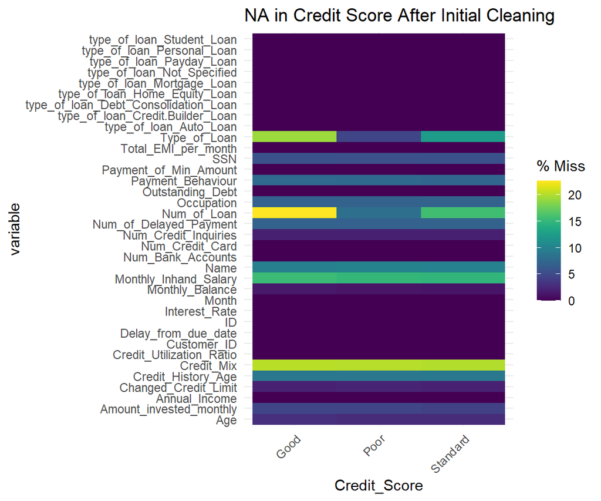

```r
# Read
df.initial <- read.csv("initial-cleaned-train.csv") %>% select(-X)
gg_miss_fct(x = df.initial, fct = Credit_Score) +
  labs(title = "NA in Credit Score After Initial Cleaning")
```

```r
remove(df.initial)
```

After the initial cleaning, it was discovered that some columns contains up to 20% missing entries. Those missing values were then imputed using the methods listed below:

1. **Num_of_Loan**: Sum of count in Type_of_Loan
2. **Payment_Behaviour, Name, Occupation, and SSN**: Mode imputation per customer ID
3. **Monthly_Inhand_Salary, Interest_Rate, Changed_Credit_Limit, and Num_Credit_Inquiries**: Median imputation per customer ID
4. **Credit_History_Age**: Convert string (e.g., ‘22 Years and 5 Months’) into a numerical count of month (e.g., 269)
5. **Num_of_Delayed_Payment and Amount_invested_monthly**: Zero value imputation

## 2.2. Feature engineering

**Split Payment_Behaviour**

For the Payment_Behavior column, the values consist of a string description combined for the type of Spending and Value of each payments. Using the pattern of the description, we split the string resulting into 2 separate columns of categorical value for the type of Spending and also type of Payment Value.

```r
step_split_payment_behaviour_column <- function(data) {
  # Split Payment_Behaviour into two new columns: Spent and Value_payment
  data$PB_Spent <- gsub("_(spent_).*", "", data$Payment_Behaviour)
  data$PB_Value_payment <- gsub(".*(Small|Medium|Large)_value_payments", "\\1", data$Payment_Behaviour)
  data <- data %>% dplyr::select(-"Payment_Behaviour")
  return(data)
}
```

**Factor with defined levels**

For this columns we use ordinal encoding to preserve the order of the categories such as, “Small” < “Medium” < “Large”.

```r
step_factor_with_order <- function(data) {
  data$PB_Spent <- factor(data$PB_Spent, levels = c("Low", "High"))
  data$PB_Value_payment <- factor(data$PB_Value_payment, levels = c("Small", "Medium", "Large"))
  data$Credit_Mix <- factor(data$Credit_Mix, levels = c("Bad", "Standard", "Good"))
  data$Credit_Score <- factor(data$Credit_Score, levels = c("Poor", "Standard", "Good"))
  return (data)
}
```

**Step encode Month**

For the Month columns, since it is a time series value, we did a cyclical encoding of the column using both Sine and Cosine value of the numerical value of the Month.

```r
step_encode_month <- function(data) {
  months <- c('January', 'February', 'March', 'April', 'May', 'June',
              'July', 'August', 'September', 'October', 'November', 'December')

  month_map <- setNames(0:11, months)

  temp <- data.frame(Month = data$Month)
  temp$month_num <- sapply(data$Month, function(x) month_map[x])

  temp$month_cos <- cos(2 * pi * temp$month_num / 12)
  temp$month_sin <- sin(2 * pi * temp$month_num / 12)

  data$month_cos <- temp$month_cos
  data$month_sin <- temp$month_sin

  data <- data %>% select(-Month)

  return (data)
}
```

**One hot encode**

A one hot encoding is implemented for the rest of categorical columns that does not have a natural ordering between them. This numeric representation is needed for the models to take the features as an input.

```r
step_one_hot_encode <- function(data, encoders) {
  df_onehot <- predict(encoders, newdata = data)
  # Remove the original columns and integrate the one-hot encoded columns back into the dataset
  data <- data %>%
    select(-Payment_of_Min_Amount, -Occupation)
  return (cbind(data, df_onehot))
}
```

## 2.3. Preprocess the data

**Dropping Irrelevant User Information Columns**

There are some columns that does not have useful information such as the user identifier information (e.g, Customer ID), this kind of columns / features are dropped from the dataset.

```r
step_drop_irrelevant_columns <- function(data) {
  data <- data %>% select(-c("Customer_ID", "ID", "Name", "SSN"))
  return(data)
}
```

To implement the whole pre-processing pipeline. First, the data is split into a train and testing set with a percentage of 80% training and 20% testing. Each of the train and test set then is inputted to the whole feature engineering functions explained above using the Pipe operator.

```r
# split data
set.seed(5003)
train_index <- createDataPartition(df$Credit_Score, p = 0.8, list = FALSE)
train_df <- df[train_index, ]
test_df <- df[-train_index, ]

# only fitted into the train data
encoders <- dummyVars(~ Payment_of_Min_Amount + Occupation, data = train_df)

train_data <- train_df %>%
  step_drop_irrelevant_columns %>%
  step_split_payment_behaviour_column %>%
  step_factor_with_order %>%
  step_encode_month %>%
  step_one_hot_encode(encoder = encoders)

test_data <- test_df %>%
  step_drop_irrelevant_columns %>%
  step_split_payment_behaviour_column %>%
  step_factor_with_order %>%
  step_encode_month %>%
  step_one_hot_encode(encoder = encoders)
```

**PCA**

An initial run of the models resulted in many memory exhaustion, some probable cause is because the data is very large. To tackle this challenge, a PCA transformation is implemented. A minimum threshold of 85% variance explained is chosen to preserve most of the dataset information, this resulted in 35 of Principle Components. A downside is introduced is that the data become less interpretable since the columns now has transformed from features into Principle Components.

```r
X_test <- test_data %>% select(-Credit_Score)  %>% data.matrix()
X_train <- train_data %>% select(-Credit_Score) %>% data.matrix()


pca_train_result <- prcomp(X_train, scale = TRUE, center = TRUE)

explained_var <- pca_train_result$sdev^2 / sum(pca_train_result$sdev^2)
cumulative_var <- cumsum(explained_var)

n_components <- which(cumulative_var >= 0.85)[1]

cat("Number of components explaining at least 85% of variance:", n_components, "\n")
```

```
## Number of components explaining at least 85% of variance: 35
```

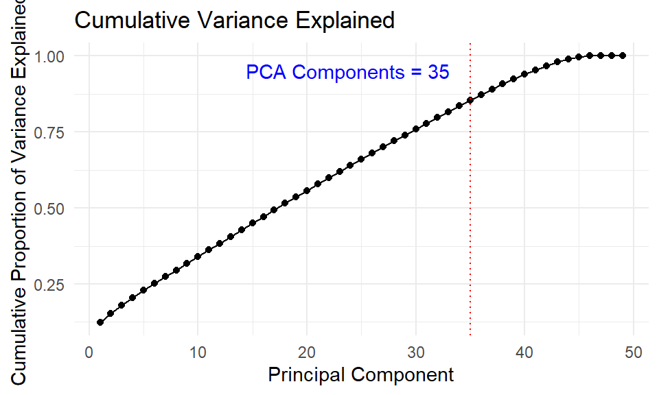

```r
df_cumulative_var <- data.frame(PC = 1:length(cumulative_var), CumulativeVariance = cumulative_var)
ggplot(df_cumulative_var, aes(x = PC, y = CumulativeVariance)) +
  geom_line() + geom_point() +
  geom_vline(xintercept = n_components, linetype="dotted", color="red") +
  annotate("text", x = n_components, y = max(df_cumulative_var$CumulativeVariance), label = paste("PCA Components =", n_components), hjust = 1.1, vjust = 1.5, color = "blue") +
  theme_minimal() +
  ggtitle("Cumulative Variance Explained") +
  xlab("Principal Component") +
  ylab("Cumulative Proportion of Variance Explained")
```

Prepare PCA features for the regression model

```r
pca_features <- pca_train_result$x[, 1:n_components]
data_train_pca <- as.data.frame(pca_features)
data_train_pca$Credit_Score <- as.numeric(train_data$Credit_Score)  # Add the target variable back
data_test_pca <- predict(pca_train_result, X_test)[, 1:n_components]
```

# 3. Classification methods

The metrics chosen to evaluate the models is Accuracy and F1-Score Weighted. Accuracy is chosen to evaluate the overall performance of the model in making predictions. Another metric chosen is F1-Score weighted; this is chosen to evaluate the model’s performance in each of the target classes. The weighted version is chosen since we have a data imbalance explained above.

```r
calculate_classification_metrics <- function(predictions, actuals, verbose=FALSE) {

  conf_matrix <- confusionMatrix(factor(predictions), factor(actuals))
  if (verbose) {
    print(conf_matrix)
  }

  accuracy <- conf_matrix$overall['Accuracy']
  conf_matrix <- as.matrix(conf_matrix$table)
  precision <- diag(conf_matrix) / rowSums(conf_matrix)
  recall <- diag(conf_matrix) / colSums(conf_matrix)
  f1_score <- 2 * precision * recall / (precision + recall)
  precision[is.nan(precision)] <- 0
  recall[is.nan(recall)] <- 0
  class_weights <- colSums(conf_matrix)

  weighted_f1_score <- sum(f1_score * class_weights, na.rm = TRUE) / sum(class_weights, na.rm = TRUE)

  if (verbose) {
    cat("Class-wise Precision:\n")
    print(precision)
    cat("Class-wise Recall:\n")
    print(recall)
    cat("Class-wise F1 Score:\n")
    print(f1_score)
    cat("Weighted F1 Score:\n")
    print(weighted_f1_score)
  }
  return (c(weighted_f1_score, accuracy))
}
```

## 3.1 Multinom

**Baseline**

The first model in the multinomial log linear model, the hyperparameter is the decay which is the weight decay value that will applies a penalty to the coefficient to regularize the model. A base model is created using the default decay of 0.

```r
# Fit the multinomial logistic regression model
multinom_model <- multinom(Credit_Score ~ ., data = data_train_pca, decay = 0, trace = FALSE)

# Predict and evaluate the model on the test data
predictions_multinom <- predict(multinom_model, newdata = data_test_pca)
metrics_multinom <- calculate_classification_metrics(predictions_multinom, as.numeric(as.factor(test_data$Credit_Score)))

df_metrics_multinom <- data.frame(
  Model = c("Base"),
  Accuracy = c(metrics_multinom[2]),
  F1Score = (metrics_multinom[1]),
  row.names = NULL
)
```

Metrics result of the base multinomial log linear model can be seen in the table below:

```r
kable(df_metrics_multinom, caption = "Base Multinomial Log Linear Model Result")
```

Base Multinomial Log Linear Model Result

| Model | Accuracy | F1Score |
| --- | --- | --- |
| Base | 0.5719572 | 0.5500165 |

**Tuned**

To tune the model, we variate the decay value using the following search space {0, 0.01, 0.1, 1, 10}. A k fold validation is also implemented with the number of 5 folds.

```r
set.seed(5003)
num_folds <- 5
data_train_pca$Credit_Score <- as.factor(data_train_pca$Credit_Score)
folds <- createFolds(data_train_pca$Credit_Score, k = num_folds)

decay_values <- c(0, 0.01, 0.1, 1, 10)
results <- data.frame(Decay = numeric(),
                      F1_Score = numeric(),
                      Accuracy = numeric())

for(decay in decay_values) {
  fold_f1_scores <- c()
  fold_acc_scores <- c()

  for(i in 1:num_folds) {
    test_indices <- folds[[i]]
    train_data_fold <- data_train_pca[-test_indices,]
    test_data_fold <- data_train_pca[test_indices,]

    multinom_model <- multinom(Credit_Score ~ ., data = train_data_fold, decay = decay, trace = FALSE)

    predictions <- predict(multinom_model, newdata = test_data_fold)

    predictions <- factor(predictions, levels = levels(test_data_fold$Credit_Score))

    conf_matrix <- confusionMatrix(predictions, test_data_fold$Credit_Score)
    precision <- conf_matrix$byClass[, "Precision"]
    recall <- conf_matrix$byClass[, "Recall"]
    f1 <- 2 * (precision * recall) / (precision + recall)

    conf_matrix_as_matrix <- as.matrix(conf_matrix$table)
    class_weights <- colSums(conf_matrix_as_matrix)

    # mean_f1 <- mean(f1, na.rm = TRUE)
    mean_f1 <- sum(f1 * class_weights, na.rm = TRUE) / sum(class_weights, na.rm = TRUE)

    accuracy <- conf_matrix$overall["Accuracy"]

    fold_acc_scores <- c(fold_acc_scores, accuracy)
    fold_f1_scores <- c(fold_f1_scores, mean_f1)
  }

  mean_f1_score <- mean(fold_f1_scores, na.rm = TRUE)
  mean_accuracy <- mean(fold_acc_scores, na.rm = TRUE)

  results <- rbind(results, data.frame(Decay = decay,
                                       F1_Score = mean_f1_score,
                                       Accuracy = mean_accuracy))
}
```

Metrics of the hyperparameter tuning compiled results can be seen in the table below:

```r
kable(results, caption = "Multinomial Log Linear Model Hyperparameter Tuning Result")
```

Multinomial Log Linear Model Hyperparameter Tuning Result

| Decay | F1_Score | Accuracy |
| --- | --- | --- |
| 0.00 | 0.5480757 | 0.5699483 |
| 0.01 | 0.5480787 | 0.5699483 |
| 0.10 | 0.5481414 | 0.5699982 |
| 1.00 | 0.5479677 | 0.5698483 |
| 10.00 | 0.5475293 | 0.5695733 |

**Best**

From the result, we can see that the best accuracy achieved by the decay value of 0.1. But if we compare this to the base model, we can see that the metrics stays the same. This is mainly because multinom use an iterative process to minimize the cost function, and we can see that even without a decay value and also a decay value of 0.1, the model manages to minimize the cost function without overshooting the value, which is typically what a decay value was mean to solve

[figure not shown]

```r
multinom_model <- multinom(Credit_Score ~ ., data = data_train_pca, decay = 0.1, trace = FALSE)

predictions_tuned_multinom <- predict(multinom_model, newdata = data_test_pca)
metrics_multinom_tuned <- calculate_classification_metrics(predictions_tuned_multinom, as.numeric(as.factor(test_data$Credit_Score)))

predicted_multinom_labels<-factor(predictions_tuned_multinom, levels = c(1, 2, 3), labels = c("Poor", "Standard", "Good"))
conf_matrix_multi <- confusionMatrix(predicted_multinom_labels, as.factor(test_data$Credit_Score))
conf_df_multi <- as.data.frame(as.table(conf_matrix$table))
names(conf_df_multi) <- c("Actual", "Predicted", "Count")

ggplot(conf_df_multi, aes(x = Actual, y = Predicted, fill = Count)) +
  geom_tile(color = "white") +
  geom_text(aes(label = Count)) +
  scale_fill_gradient(low = "white", high = "steelblue") +
  theme_minimal() +
  labs(x = "Actual", y = "Predicted", title = "Confusion Matrix - Best Multinom Model") +
  theme(legend.position = "bottom")
```

```r
df_tuned_multinom <- rbind(df_metrics_multinom, c("Tuned", metrics_multinom_tuned[2], metrics_multinom_tuned[1]))
kable(df_tuned_multinom, caption = "Multinomial Log Linear Best Model vs Base Model Result")
```

Multinomial Log Linear Best Model vs Base Model Result

| Model | Accuracy | F1Score |
| --- | --- | --- |
| Base | 0.571957195719572 | 0.550016509750782 |
| Tuned | 0.571957195719572 | 0.550016509750782 |

## 3.2 LDA

Linear Discrimant(LDA) Analysis is A dimensionality reduction technique commonly used for supervised classification problems. LDA has a goal to project the dataset onto a lower-dimensional space while maximizing the class separability

**Baseline**

For the base model, default parameters are used and the model is trained using 5 folds cross validation.

```r
set.seed(5003)
train_control_lda <- trainControl(method = "cv", number = 5)
# Train the LDA model using 5-fold cross-validation
cv_model_lda <- train(factor(Credit_Score) ~ .,
                  data = data_train_pca,
                  method = "lda",
                  trControl = train_control_lda)

lda_predictions <- predict(cv_model_lda, newdata = data.frame(data_test_pca))
predictions_lda <- lda_predictions
metrics_lda <- calculate_classification_metrics(predictions_lda, as.numeric(test_data$Credit_Score))

df_metrics_lda <- data.frame(
  Metric = c("Accuracy", "F1 Score"),
  Value = c(metrics_lda[2], metrics_lda[1]),
  row.names = NULL  # This will remove the first column (row names)
)
kable(df_metrics_lda, caption = "LDA Classification Metrics")
```

LDA Classification Metrics

| Metric | Value |
| --- | --- |
| Accuracy | 0.5767577 |
| F1 Score | 0.5656116 |

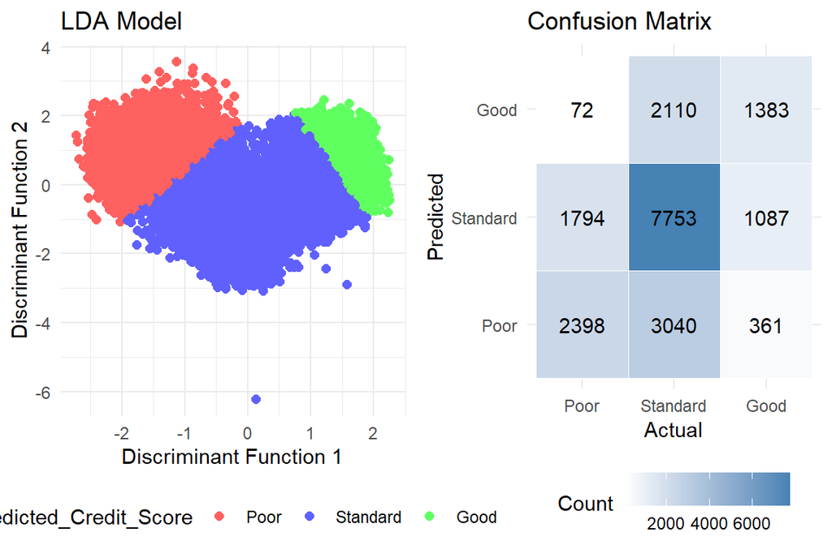

```r
lda_values <- predict(cv_model_lda$finalModel, newdata = data.frame(data_test_pca))
predicted_lda_labels<-factor(predictions_lda, levels = c(1, 2, 3), labels = c("Poor", "Standard", "Good"))
lda_data_test <- data.frame(lda_values$x, Predicted_Credit_Score = predicted_lda_labels)

p1_lda <- ggplot(lda_data_test, aes(x = LD1, y = LD2, color = Predicted_Credit_Score)) +
  geom_point(size = 2) +
  scale_color_manual(values = colors) +
  scale_fill_manual(values = colors) +
  labs(title = "LDA Model",
       x = "Discriminant Function 1",
       y = "Discriminant Function 2") +
  theme_minimal() +
  theme(legend.position = "bottom")


conf_matrix <- confusionMatrix(predicted_lda_labels, as.factor(test_data$Credit_Score))

conf_df <- as.data.frame(as.table(conf_matrix$table))
names(conf_df) <- c("Actual", "Predicted", "Count")

p2_lda <- ggplot(conf_df, aes(x = Actual, y = Predicted, fill = Count)) +
  geom_tile(color = "white") +
  geom_text(aes(label = Count)) +
  scale_fill_gradient(low = "white", high = "steelblue") +
  theme_minimal() +
  labs(x = "Actual", y = "Predicted", title = "Confusion Matrix") +
  theme(legend.position = "bottom")

grid.arrange(p1_lda, p2_lda, ncol = 2)
```

## 3.3 Random Forest

**Baseline**

Initial random forest model is trained using whole train_data, some parameters will be tuned later and now it leaved as default except for the importance, impurity is used so the features importance are calculated. The parameters are:

1. num.trees : number of trees that will be grown on the random forest, default is 500
2. max.depth : maximum of depth/ level for each trees, default is NULL or 0 where the trees are let fully grown until pure
3. min.node.size : minimum number of samples on the leaf node, default is 1 for classification.

```r
# train initial random forest model

set.seed(5003)

X_test_rf <- test_data %>% dplyr::select (-"Credit_Score")
model_rf <- ranger(Credit_Score ~ ., data = train_data, importance = 'impurity', verbose = FALSE)

predictions_rf <- predict(model_rf, data = X_test_rf)
metrics_rf <- calculate_classification_metrics(predictions_rf$predictions, test_data$Credit_Score)
```

**Tuned**

1. num.trees : 700
2. max.depth : 0 (same as default)
3. min.node.size : 1 (same as default)

```r
# codes to do manual grid search using for loop

num_folds <- 2
folds <- createFolds(train_data$Credit_Score, k = num_folds)

num.trees <- c(300, 500, 700)
max.depth <- c(0, 10, 15)
min.node.size <- c(1, 3, 5)
importance <- c('impurity')

results_df <- data.frame(
  ntree = integer(),
  maxdepth = integer(),
  nodesize = integer(),
  mean_f1 = numeric(),
  mean_accuracy = numeric(),
  stringsAsFactors = FALSE
)

for(nt in num.trees) {
  for(md in max.depth) {
    for(mns in min.node.size) {
      for (imp in importance) {
        fold_f1_scores <- c()
        fold_accuracy <- c()

        for(i in 1:num_folds) {
          test_indices <- folds[[i]]
          train_data_fold <- train_data[-test_indices,]
          test_data_fold <- train_data[test_indices,]

          rf_model <- ranger(
            Credit_Score ~ .,
            data = train_data_fold,
            num.trees = nt,
            max.depth = md,
            min.node.size = mns,
            importance = imp,
            verbose = FALSE
          )

          predictions <- predict(rf_model, test_data_fold)$predictions

          if(is.factor(test_data_fold$Credit_Score)) {
            predictions <- factor(predictions, levels = levels(test_data_fold$Credit_Score))
          }

          f1 <- calculate_classification_metrics(test_data_fold$Credit_Score, predictions)

          fold_f1_scores <- c(fold_f1_scores, f1[1])
          fold_accuracy <- c(fold_f1_scores, f1[2])
        }

        mean_f1 <- mean(fold_f1_scores)
        mean_accuracy <- mean(fold_accuracy)

        new_row <- data.frame(
          ntree = nt,
          maxdepth = md,
          nodesize = mns,
          mean_f1 = mean_f1,
          mean_accuracy = mean_accuracy,
          stringsAsFactors = FALSE
        )

        results_df <- rbind(results_df, new_row)
      }
    }
  }
}

results_df <- results_df[order(results_df$mean_f1, decreasing = TRUE), ]
results_df <- results_df %>% tibble::rownames_to_column(var = "Index")
```

```r
kable(head(results_df, 5), caption = "Top 5 Rows of Grid Search Iteration")
```

Top 5 Rows of Grid Search Iteration

| Index | ntree | maxdepth | nodesize | mean_f1 | mean_accuracy |
| --- | --- | --- | --- | --- | --- |
| 19 | 700 | 0 | 1 | 0.7864121 | 0.7866866 |
| 10 | 500 | 0 | 1 | 0.7853842 | 0.7856930 |
| 11 | 500 | 0 | 3 | 0.7852078 | 0.7855754 |
| 1 | 300 | 0 | 1 | 0.7849047 | 0.7849400 |
| 20 | 700 | 0 | 3 | 0.7844418 | 0.7847898 |

```r
# train random forest model using best parameters found
set.seed(5003)

# adding class weight to the model
class_freq <- table(test_data$Credit_Score)
class_weights <- 1 / class_freq
case_weights <- class_weights[test_data$Credit_Score]

tuned_model_rf <- ranger(Credit_Score ~ ., data = train_data, num.tree = 700, max.depth = 0, min.node.size = 1, importance = 'impurity', class.weights = class_weights, verbose = FALSE)

predictions_tuned_rf <- predict(tuned_model_rf, data = X_test_rf)
metrics_tuned_rf <- calculate_classification_metrics(predictions_tuned_rf$predictions, test_data$Credit_Score)
```

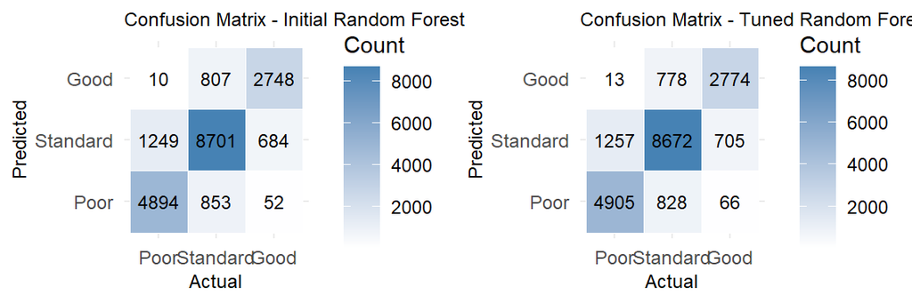

```r
plot_confusion_matrix <- function(conf_matrix, title = "Confusion Matrix") {

  conf_df <- as.data.frame(as.table(conf_matrix))
  names(conf_df) <- c("Actual", "Predicted", "Count")

  ggplot(conf_df, aes(x = Actual, y = Predicted, fill = Count)) +
    geom_tile(color = "white") +
    geom_text(aes(label = Count), size = 3) +
    scale_fill_gradient(low = "white", high = "steelblue") +
    labs(x = "Actual", y = "Predicted", title = title) +
    theme_minimal() +
    theme(
      plot.title = element_text(size = 9),
      axis.title = element_text(size = 9),
      axis.text = element_text(size = 9)
    )
}

conf_matrix_model_rf <- confusionMatrix(predictions_rf$predictions, test_data$Credit_Score)
conf_matrix_model_rf_tuned <- confusionMatrix(predictions_tuned_rf$predictions, test_data$Credit_Score)

plot_rf <- plot_confusion_matrix(conf_matrix_model_rf, "Confusion Matrix - Initial Random Forest")
plot_rf_tuned <- plot_confusion_matrix(conf_matrix_model_rf_tuned, "Confusion Matrix - Tuned Random Forest")

grid.arrange(plot_rf, plot_rf_tuned, ncol = 2)
```

After training the model using best found parameters and weighted class, the model can predict class label “poor” and “good” better compared to initial model as shown in the confusion matrix above.

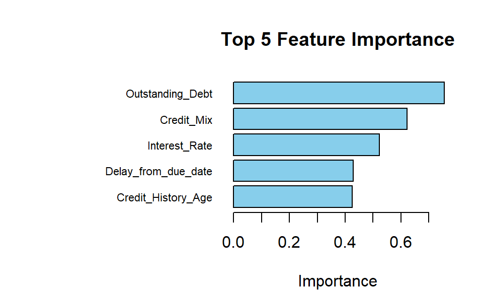

```r
feature_importance <- importance(tuned_model_rf)
feature_importance <- sort(feature_importance, decreasing = TRUE)

top_feature <- head(feature_importance, 5)
top_feature <- rev(top_feature)

par(mar = c(4, 12, 4, 2))

barplot(
  top_feature,
  main = "Top 5 Feature Importance",
  xlab = "Importance",
  ylab = "",
  col = "skyblue",
  las = 1,  # Make labels horizontal
  horiz = TRUE,
  cex.names = 0.7
)
```

Using the feature importance function in the ranger package we can show the importance of each features. A feature importance plot is also visualized where it is shown that the most important features in the dataset is “Outstanding_Debt”.

```r
f1_score_rf <- metrics_rf[1]
f1_score_tuned_rf <- metrics_tuned_rf[1]

accuracy_rf <- metrics_rf[2]
accuracy_tuned_rf <- metrics_tuned_rf[2]

f1_table_rf <- data.frame(
  Model = c("Initial RF", "Tuned RF"),
  Accuracy = c(accuracy_rf, accuracy_tuned_rf),
  F1_Score = c(f1_score_rf, f1_score_tuned_rf)
)

kable(f1_table_rf, caption = "Comparison of RF Accuracy and F1-Score")
```

Comparison of RF Accuracy and F1-Score

| Model | Accuracy | F1_Score |
| --- | --- | --- |
| Initial RF | 0.8172317 | 0.8172199 |
| Tuned RF | 0.8176318 | 0.8177022 |

The model then trained using best parameter, also class_weight parameter is added, which set to inversely proportional from the class size. The F1-score is slightly increased for the tuned model, and the performance on predicting class label “poor” and “good” are slightly better.

## 3.4 XGBoost

```r
num_classes <- length(unique(train_data$Credit_Score))
train_Credit_Score_xgb <- as.numeric(train_data$Credit_Score) - 1
```

**Baseline**

First, we Initialize the model,then training the XGBoost model with fixed parameters, make predictions and calculating the F1 Score of the base model.

```r
train_matrix <- xgb.DMatrix(data = X_train, label=train_Credit_Score_xgb)
test_matrix <- xgb.DMatrix(data = X_test)

params <- list(
    objective = "multi:softprob",
    num_class = num_classes,
    booster = "gbtree",
    eval_metric = "mlogloss",
    eta = 0.3,    # learning rate
    max_depth = 6 # max depth of trees
)

model_xgboost <- xgb.train(params = params, data = train_matrix, nrounds = 100)

predictions_xgb<- predict(model_xgboost, test_matrix)
predicted_classes_xgb <- max.col(matrix(predictions_xgb, byrow = TRUE, ncol = num_classes))

actual_classes <- factor(test_data$Credit_Score, levels = 0:(length(unique(train_data$Credit_Score))))

predicted_classes_xgb <- factor(predicted_classes_xgb, levels = levels(actual_classes))
f1_xgb_initial <- calculate_classification_metrics(predicted_classes_xgb, as.numeric(test_data$Credit_Score))
```

**Tuned**

Performing Grid search for eta and max depth by using cross validation with 5 folds and saving all the F1 score with each iterations. eta is the learning rate parameter in XGBoost. Lower values make the model more robust to overfitting. max_depth is the maximum depth of the trees used in the model. Smaller value of trees are simpler and less likely to overfit, whereas deeper trees are more complex and can capture more detailed patterns but more prone to overfitting.

```r
param_grid <- expand.grid(
  eta = c(0.1, 0.3, 0.6),       # Reduced the range of learning rates
  max_depth = c(3, 6, 9),       # Shallower trees
  stringsAsFactors = FALSE
)

cv_results <- list()

for(i in seq_len(nrow(param_grid))) {
  params <- list(
    booster = "gbtree",
    objective = "multi:softprob",
    num_class = num_classes,
    eval_metric = "mlogloss",
    eta = param_grid$eta[i],
    max_depth = param_grid$max_depth[i]
  )

  cv_model <- xgb.cv(
    params = params,
    data = train_matrix,
    nrounds = 50,
    nfold = 5,
    showsd = TRUE,
    stratified = TRUE,
    print_every_n = 10,
    early_stopping_rounds = 20,
    maximize = FALSE,
    verbose = 0
  )

  cv_results[[i]] <- list(
    Params = params,
    Model = cv_model
  )
}

best_model <- cv_results[[which.min(sapply(cv_results, function(x) min(x$Model$evaluation_log$test_mlogloss_mean)))]]
best_model <- cv_results[[which.min(sapply(cv_results, function(x) min(x$Model$evaluation_log$test_mlogloss_mean)))]]

best_params <- best_model$Params
final_model <- xgb.train(best_params, train_matrix, nrounds = length(best_model$Model$evaluation_log$test_mlogloss_mean))

predictions_xgb_final <- predict(final_model, test_matrix)
predicted_classes_xgb_final <- max.col(matrix(predictions_xgb_final, byrow = TRUE, ncol = num_classes))
predicted_classes_xgb_final <- factor(predicted_classes_xgb_final, levels = levels(actual_classes))

f1_xgb_grid <- calculate_classification_metrics(predicted_classes_xgb_final, as.numeric(test_data$Credit_Score))
```

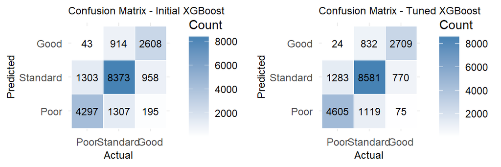

```r
predictions_xgboost_factor <- factor(predicted_classes_xgb, levels = c("1", "2", "3"), labels = c("Poor", "Standard", "Good"))
conf_matrix_base <- confusionMatrix(predictions_xgboost_factor, test_data$Credit_Score)

predictions_xgboost_factor_final <- factor(predicted_classes_xgb_final, levels = c("1", "2", "3"), labels = c("Poor", "Standard", "Good"))
conf_matrix_tuned <- confusionMatrix(predictions_xgboost_factor_final, test_data$Credit_Score)

plot_xgb <- plot_confusion_matrix(conf_matrix_base, "Confusion Matrix - Initial XGBoost")
plot_xgb_tuned <- plot_confusion_matrix(conf_matrix_tuned, "Confusion Matrix - Tuned XGBoost")

grid.arrange(plot_xgb, plot_xgb_tuned, ncol = 2)
```

Mapping the numeric output back as categorical string of “Poor”, “Standard” and “Good”. Creating the Confusion Matrix of the base model and plotting the matrix based on data count. Creating the Confusion Matrix of the tuned model using the best parameter from the grid search and plotting the matrix based on data count. The final result shows both the accuracy and F1 score shows an increase from the base model to the tuned model.

```r
f1_score_xgb <- f1_xgb_initial[1]
f1_score_tuned_xgb <- f1_xgb_grid[1]

accuracy_xgb <- f1_xgb_initial[2]
accuracy_tuned_xgb <- f1_xgb_grid[2]

f1_table_xgb <- data.frame(
  Model = c("Initial XGBoost", "Tuned XGBoost"),
  Accuracy = c(accuracy_xgb, accuracy_tuned_xgb),
  F1_Score = c(f1_score_xgb, f1_score_tuned_xgb)
)

kable(f1_table_xgb, caption = "Comparison of XGBoost Accuracy and F1-Score")
```

Comparison of XGBoost Accuracy and F1-Score

| Model | Accuracy | F1_Score |
| --- | --- | --- |
| Initial XGBoost | 0.7639764 | 0.7642058 |
| Tuned XGBoost | 0.7948295 | 0.7948847 |

Using the feature importance embedded in the XGBoost model we can show the rank and importance of each features used for the model. A feature importance plot is also visualized where it is shown that the most important features in the dataset is “Outstanding_Debt”.

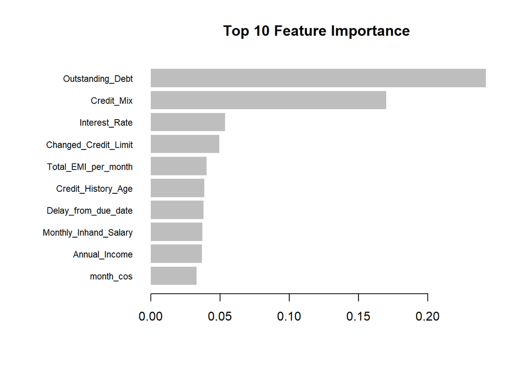

```r
# Calculate feature importance
importance_matrix <- xgb.importance(model = final_model)
top_10_importance <- head(importance_matrix, n = 10)


xgb.plot.importance(top_10_importance, main = "Top 10 Feature Importance")
```

# 4. Results

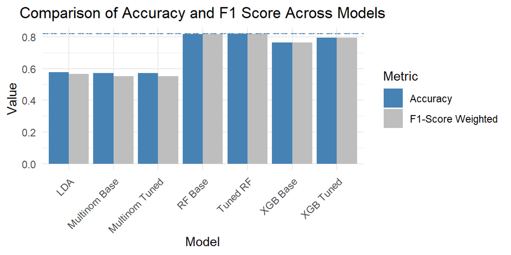

```r
combined_metrics <- rbind(
  metrics_multinom,
  metrics_multinom_tuned,
  metrics_lda,
  metrics_rf,
  metrics_tuned_rf,
  f1_xgb_initial,
  f1_xgb_grid
)

combined_metrics_df <- as.data.frame(combined_metrics)
combined_metrics_df$model <- c("Multinom Base", "Multinom Tuned", "LDA", "RF Base", "Tuned RF", "XGB Base", "XGB Tuned")
combined_metrics_df <- combined_metrics_df %>%
  rename(`F1-Score Weighted` = V1)

long_metrics_df <- pivot_longer(combined_metrics_df, cols = -model, names_to = "Metric", values_to = "Value")
max_accuracy <- max(long_metrics_df$Value[long_metrics_df$Metric == "Accuracy"])
max_f1_score <- max(long_metrics_df$Value[long_metrics_df$Metric == "F1-Score Weighted"])

ggplot(long_metrics_df, aes(x = model, y = Value, fill = Metric)) +
  geom_bar(stat = "identity", position = position_dodge()) +
  theme_minimal() +
  labs(title = "Comparison of Accuracy and F1 Score Across Models",
       x = "Model",
       y = "Value",
       fill = "Metric") +
  scale_fill_manual(values = c("Accuracy" = "steelblue", "F1-Score Weighted" = "gray")) +
  geom_hline(aes(yintercept = max_accuracy), color = "steelblue", size = 0.5, linetype = "longdash") +
  geom_hline(aes(yintercept = max_f1_score), color = "gray", size = 0.5, linetype = "dotted") +
  theme(plot.title = element_text(hjust = 0.5),
        axis.text.x = element_text(angle = 45, hjust = 1))
```

The plot above show the comparison of all four models’ performances. It can be seen that the multinomial and LDA models perform similarly, while XGBoost and Random Forest outperform them both. Random Forest has the best performance with the highest accuracy and F1-Score.

One of the reasons for this is that the tree-based method excels in making predictions of tabular data since it can create a nonlinear boundary more easily than the multinomial and LDA models, hence the better performance the model results. We can see this more clearly in Section 3.2, where the LDA splits the data linearly.

A high accuracy score indicates a strong overall ability of the model to correctly classify clients into their respective credit score categories (Good, Standard, Poor). A high F1 Score signifies a well-balanced model in terms of precision (finding true good credit scores) and recall (identifying all deserving good credit scores) across all classes (Good, Standard, Poor). This shows that the model can provide good predictions for each class without sacrificing the quality of predictions for other classes.

Another thing that can be compared is that Multinom and LDA were unable to use the full data without reducing the dimensionality of the data first. On the other hand, this was not needed for both Random Forest and XGBoost models. This ability to process the full data is an advantage for Random Forest and XGBoost since the feature importance can be exported and it can be interpreted compared to the other two models.

The final selected model for the Credit Score classification data is **Random Forest.**

# 5. Discussion and conclusion

When developing our models, we encountered a few setbacks such as:

1. Grid search consumes relatively long time. Also due to limited memory resource, we only tested limited combinations of hyper parameters.
2. The Caret library’s limited flexibility requires adjustments to algorithms and data formats for various models.
3. Some model that we developed have some limitations in predicting the model (“Memory Exhausted”). PCA was applied to overcome this problem. However, it leads to low interpretability of important features that affect the target.

Based on the comparison of each model, this study concludes that Random Forest perform the best for the project. Firstly, it achieved a significantly higher Weighted F1-score, demonstrating its exceptional ability to accurately classify clients across all credit score categories (Good, Standard, Poor). Secondly, Random Forest’s capability to use the full data without dimensionality reduction preserved more information for better prediction. Finally, the model’s built-in feature importance function provided greater interpretability.

For further model improvements, we suggest:

1. Finding and combining other dataset to make the sample larger.
2. Trying more combination of hyperparameters.
3. Using sampling methods like under sampling or SMOTE (Synthetic Minority Over-Sampling Technique).
4. Exploring other libraries such as (“superml”) that consists many machine learning function.
5. Additional Metric (ROC-AUC) to explain the model more precisely.
6. Consult with experts in Banking Industry to provide additional information.